# Gentrification

```r
# Libraries
library(tidyverse)
library(sf)
library(lubridate)
library(leaflet)
if (!require(leaflet.extras)) {
  devtools::install_github('bhaskarvk/leaflet.extras')
  library(leaflet.extras)
}
library(compare)

# Parameters
  # File where generated answers are saved, by default in the home directory
file_answers <- "../data/answers.rds"
  # File containing UDP data
file_udp <- "../data/cci_rews_data_2015-08-21 with amenity data.xlsx"
  # File only containing typology of each tract
file_typologies <- "../data/udp_2017results.csv"
  # Typology map colors
typology_colors <-
  c(
    "LI - At Risk of Gentrification and/or Displacement" = "#c3c4df",
    "LI - Not Losing Low Income Households"              = "#e1dfee",
    "LI - Ongoing Gentrification and/or Displacement"    = "#a598c7",
    "MHI - Advanced Exclusion"                           = "#e9a58a",
    "MHI - Advanced Gentrification"                      = "#736a8a",
    "MHI - At Risk of Exclusion"                         = "#fcd9b8",
    "MHI - Not Losing Low Income Households"             = "#fef6ec",
    "MHI - Ongoing Exclusion"                            = "#fdbb95",
    "College town"                                       = "gray",
    "Data Unavailable or Unreliable"                     = "gray"
  )
  # WGS-84 projection for San Francisco
WGS84 <- "+proj=longlat +ellps=WGS84 +datum=WGS84 +no_defs"
  # Redlining map colors
redlining_colors <-
  c(
    "A" = "green",
    "B" = "blue",
    "C" = "yellow",
    "D" = "red"
  )
  # File for construction pipeline in SF
file_pipeline <- "../data/pipeline_data.rds"
  # Save answers
SAVE_ANSWERS <- TRUE
  # File for tract geographies
file_tracts <- "../data/14000.shp"
  # File for redlining geographies
file_redlining <- "../data/HOLC_SanFrancisco.shp"
```

The [Urban Displacement Project](http://www.urbandisplacement.org/) (UDP) is a collaborative research initiative by UC Berkeley, UCLA, and Portland State University. Its aim is to understand the nature of gentrification and displacement in American cities, and one of its major areas of focus is San Francisco.

UDP has published a list of gentrification “typologies”. This is a framework by which census tracts can be classified according to the extent of gentrification and exclusion taking place within them. Note that gentrification refers to demographic shifts in historically disinvested neighborhoods, often corresponding to the displacement of low-income residents, whereas exclusion refers to increasing barriers for low-income residents to move into an area.

UDP’s map of San Francisco, colored by typology, is available [here](http://www.urbandisplacement.org/map/sf). The first task in this challenge is to recreate this map.

First, we need to get the shapes of the census tracts. From the [ACS data website](https://factfinder.census.gov/faces/nav/jsf/pages/searchresults.xhtml?refresh=t), download the shapefile for census tracts as follows:

1. Select the “Census Tract - 140” geography for all census tracts in California
2. Select dataset ID S0101 (Age and Sex)
3. Select “Create a Map” and make a map of the variable “Total population”
4. Download the shapefiles and transfer all of them into your data directory.

Note that when calling `read_sf()`, you should read in the .shp file.

**q1.1** `file_typologies` contains the typology of some census tracts in the Bay Area under the column `Typology`, while `file_udp_data` contains the typologies under the column `disp_descr` as well as several other variables used to create the typologies. Both files are raw data obtained from the UDP researchers. Note that `file_udp_data` contains data on fewer census tracts than `file_typologies`.

Use `count` to look at the typology results in both files. What major differences do you notice?

Read in both files so we can compare them.

```r
udp_data <-
  file_udp %>%
  readxl::read_excel(sheet = "data")
typologies <-
  file_typologies %>%
  read_csv() %>%
  select(geo_fips, Typology)
```

Compare the tract IDs in both.

```r
nrow(typologies) - nrow(udp_data)
```

```
## [1] 551
```

`typologies` contains data on 551 more census tracts than `udp_data`.

```r
setdiff(
  udp_data %>% pull(tract_id),
  typologies %>% pull(geo_fips)
)
```

```
## numeric(0)
```

All the tract IDs that are in `udp_data` are also in `typologies`.

```r
udp_data %>%
  select(tract_id, disp_descr) %>%
  count(disp_descr)
```

```
## # A tibble: 9 x 2
##   disp_descr                                                             n
##   <chr>                                                              <int>
## 1 College town                                                          11
## 2 LI - Advanced gentrification                                         149
## 3 LI - At risk of gentrification or displacement                       290
## 4 LI - Not losing LI households or very early stages of displacement   329
## 5 LI - Undergoing displacement                                          63
## 6 MHI - Advanced exclusion                                              28
## 7 MHI - At risk of displacement                                        132
## 8 MHI - Not losing LI households or very early stages of displaceme…   476
## 9 MHI - Undergoing displacement                                        102
```

```r
typologies %>%
  count(Typology)
```

```
## # A tibble: 10 x 2
##    Typology                                               n
##    <chr>                                              <int>
##  1 College Town                                          15
##  2 Data Unavailable or Unreliable                        58
##  3 LI - At Risk of Gentrification and/or Displacement   308
##  4 LI - Not Losing Low Income Households                402
##  5 LI - Ongoing Gentrification and/or Displacement      320
##  6 MHI - Advanced Exclusion                              35
##  7 MHI - Advanced Gentrification                         98
##  8 MHI - At Risk of Exclusion                           312
##  9 MHI - Not Losing Low Income Households               383
## 10 MHI - Ongoing Exclusion                              200
```

Doing a count for both files, it is clear that the terminology used in both is not consistent. `typologies` makes a distinction between gentrification and exclusion, while `udp_data` makes no such distinction, and seems to only make distinctions by extent of gentrification and income. This is seen from the fact that `udp_data` contains categories for “Undergoing displacement” for both low income and moderate-to-high income.

**q1.2** `file_typologies` contains typology results that are more consistent with the map we are trying to recreate, so we will use it for mapping. However, `file_typologies` has no way to filter the tracts by city, so we have to use the filtered census tract IDs in `file_udp_data` to determine which tracts to map. Join the typologies data with the geographies you just downloaded, and use the color values in `typology_colors` to recreate the UDP map for the city of San Francisco. What conclusions can you draw?

Note that your map will look a little different from the original, partially because the original uses base maps, and partially because the original uses striped colors for “Advanced Gentrification” that are hard to recreate in R.

Hints:

- Make sure to use `st_transform` with the WGS84 projection defined above.
- Use [this website](http://www.usboundary.com/Areas/) on census tract boundaries to find out which tract you could filter out to better focus on the main peninsula, rather than the offshore islands.

```r
tracts <-
  file_tracts %>%
  read_sf() %>%
  mutate(
    GEO_ID =
      str_remove(GEO_ID, "\\d+US") %>%
      as.double()
  ) %>%
  st_transform(crs = WGS84)
```

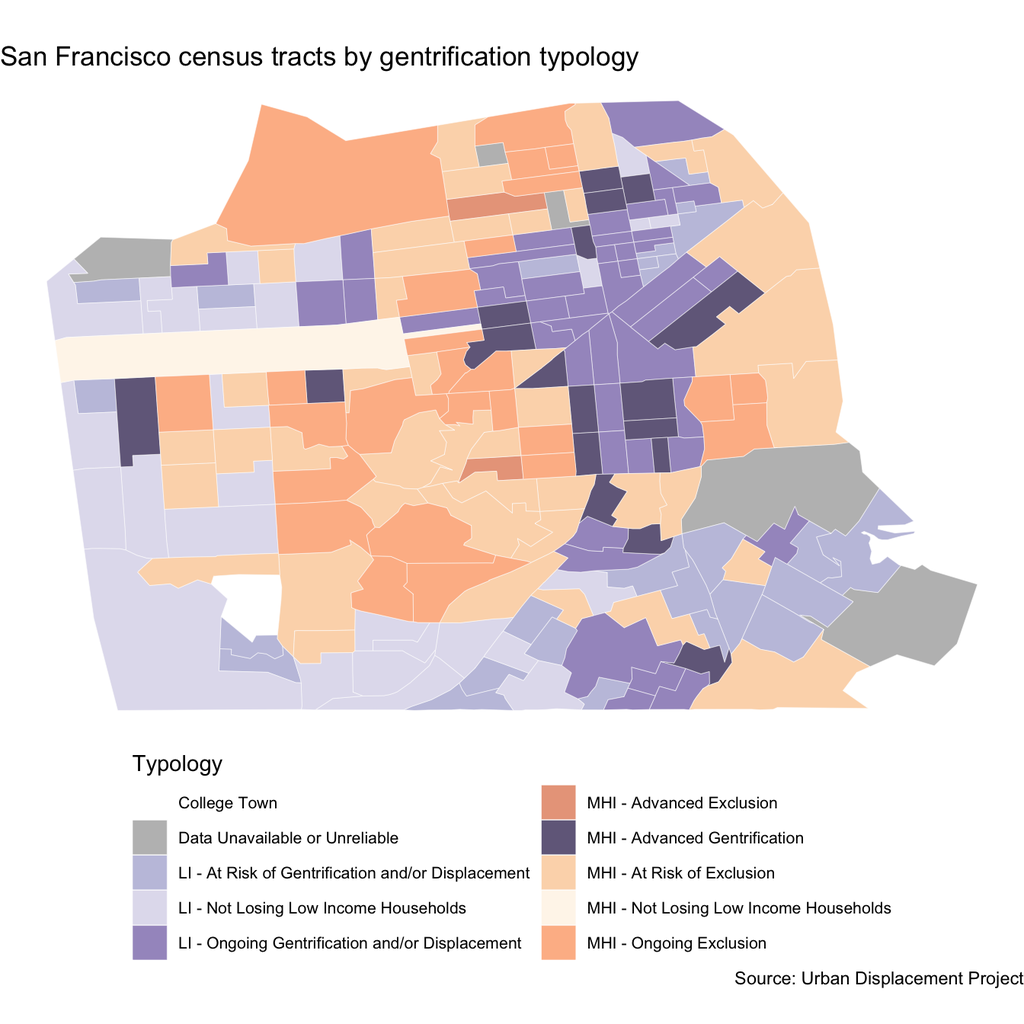

```r
udp_data %>%
  filter(city == "San Francisco") %>%
  select(tract_id) %>%
  filter(tract_id != 6075017902) %>%
  left_join(typologies, by = c("tract_id" = "geo_fips")) %>%
  left_join(tracts, by = c("tract_id" = "GEO_ID")) %>%
  ggplot(aes(fill = Typology)) +
  geom_sf(size = 0.1, color = "white") +
  scale_fill_manual(values = typology_colors) +
  coord_sf(datum = NA) +
  guides(
    fill =
      guide_legend(
        title.position = "top",
        ncol = 2
      )
  ) +
  theme_void() +
  theme(
    legend.position = "bottom",
    legend.text = element_text(size = 8)
  ) +
  labs(
    title = "San Francisco census tracts by gentrification typology",
    caption = "Source: Urban Displacement Project"
  )
```

```r
# Print results
if (exists("q1.2")) q1.2

# Compare result with answer
if (exists("q1.2")) knitr::include_graphics("data/q1_2.png")
```

The areas being gentrified and the areas under exclusion tend to cluster together. Moreover, even within the clusters of tracts being gentrified, those which are advanced tend to cluster together. Since all the gentrification typologies are low-income except “Advanced Gentrification”, this suggests that there are high-income pockets clustered together amongst low-income gentrifying pockets.

**q2** Gentrification and exclusion are deeply rooted in historical state policies. In this question, we explore the history of redlining, where certain areas were identified by the state as less worth of investment because they contained high proportions of minority populations.

The [Mapping Inequality Project](https://dsl.richmond.edu/panorama/redlining/#loc=4/36.71/-96.93&opacity=0.8) at the University of Richmond has made shapefiles available which identify exactly how areas were redlined in the past. Download the shapefiles for San Francisco (use the cloud icon next to the label “San Francisco, CA”) and add them to your data directory.

Overlay the redlining data from the mapping inequality project with the plot you created in q1.2. What conclusions can you draw?

Hints:

- Again, remember to use `st_transform` to make the projections of the two shapefiles consistent.
- Use `alpha` to make the colors more clear in the overlay.
- Note that `ggplot` does not allow multiple legends for the same aesthetic. Think of ways in which you can separate the legends for the redlining zones and the gentrification typologies!

```r
redlining <-
  file_redlining %>%
  read_sf() %>%
  st_transform(crs = WGS84)
```

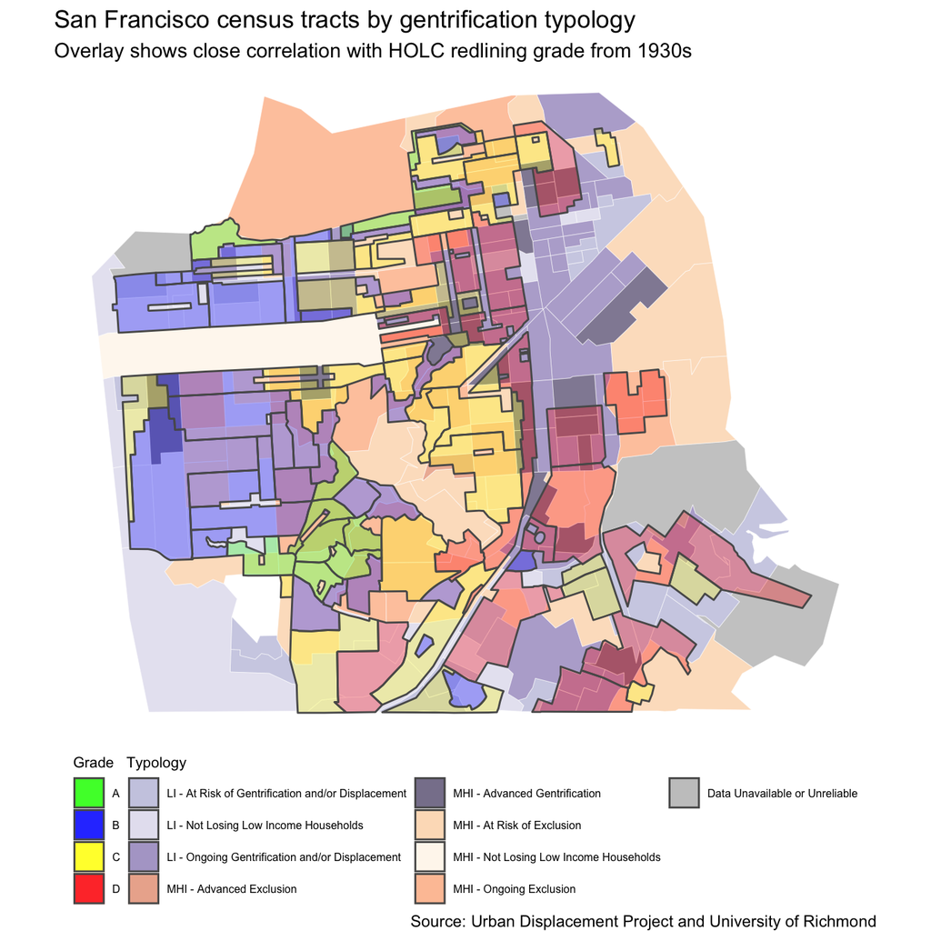

```r
udp_data %>%
  filter(city == "San Francisco") %>%
  select(tract_id) %>%
  filter(tract_id != 6075017902) %>%
  left_join(typologies, by = c("tract_id" = "geo_fips")) %>%
  left_join(tracts, by = c("tract_id" = "GEO_ID")) %>%
  ggplot(aes(fill = Typology)) +
  geom_sf(size = 0.1, color = "white", alpha = 0.8) +
  geom_sf(
    aes(fill = holc_grade),
    data = redlining,
    inherit.aes = FALSE,
    alpha = 0.3
  ) +
  scale_fill_manual(
    breaks =
      c(
        redlining_colors %>% names(),
        typology_colors %>% names()
      ),
    values = c(typology_colors, redlining_colors)
  ) +
  guides(
    fill =
      guide_legend(
        title.position = "top",
        ncol = 4
      )
  ) +
  coord_sf(datum = NA) +
  theme_void() +
  theme(
    legend.position = "bottom",
    legend.title = element_text(size = 8),
    legend.text = element_text(size = 6)
  ) +
  labs(
    title = "San Francisco census tracts by gentrification typology",
    subtitle =
      "Overlay shows close correlation with HOLC redlining grade from 1930s",
    fill = "Grade   Typology",
    caption = "Source: Urban Displacement Project and University of Richmond"
  )
```

```r
# Print results
if (exists("q2")) q2

# Compare result with answer
if (exists("q2")) knitr::include_graphics("data/q2.png")
```

In general, the areas being gentrified correspond closely to the areas that got the lowest HOLC grade, while the areas under exclusion correspond to higher HOLC grades. The policies of the 1930s-1940s thus clearly had a close correlation with housing inequality today.

There are some exceptions: in the east of the city, there is a tract that is classified as under exclusion but was redlining grade “D”, whereas in the west, there is a tract that is undergoing advanced gentrification and was redlining grade “B”. This suggests that there are probably pockets of the city whose income demographics have changed significantly since the 1930s and 1940s.

**q3.1** Next, we will try to understand how current patterns of housing construction relate to housing inequality.

Every quarter, the San Francisco Planning Department releases a “Development Pipeline” document which lists all the current construction projects in the city. This document includes the total number of units being constructed, as well as how many of those units constitute affordable housing.

The data for every quarter from 2013-2017 has been downloaded, cleaned, and stored for you in `file_pipeline`. However, the `coordinates` column must be converted into a geometrical object before we can map the data.

Read in the data, and use the `st_as_sf` function to convert the coordinates into simple geometrical objects.

Hints:

- The coordinates column is in the format (latitude, longitude). Use `separate` and `str_extract` to get those numbers as separate columns.
- `st_as_sf` takes a `coords` argument in the form (longitude, latitude). You can filter for rows that have non-NA values for both coordinates.

```r
q3.1 <-
  file_pipeline %>%
  read_rds() %>%
  separate(col = coords, into = c("lat", "lng"), sep = ",\\s*") %>%
  mutate(
    lat = str_extract(lat, "-?\\d+.?\\d*") %>% as.numeric(),
    lng = str_extract(lng, "-?\\d+.?\\d*") %>% as.numeric()
  ) %>%
  filter_at(
    vars(lat, lng),
    all_vars(!is.na(.))
  ) %>%
  st_as_sf(coords = c("lng", "lat"))
# Print results
if (exists("q3.1")) q3.1
```

```
## Simple feature collection with 4762 features and 26 fields
## geometry type:  POINT
## dimension:      XY
## bbox:           xmin: -122.5094 ymin: 37.70807 xmax: -122.2806 ymax: 37.82428
## epsg (SRID):    NA
## proj4string:    NA
## # A tibble: 4,762 x 27
##    neighborhood date       units net_units description       zoning     sf
##    <chr>        <date>     <int>     <int> <chr>             <chr>   <dbl>
##  1 Northeast    2012-10-31     9         9 <NA>              RM-1   0.
##  2 Northeast    2012-07-12     0         0 Hospital Replace… CRNC   1.41e5
##  3 Downtown     2009-04-08   165       165 THC/Citizens Hou… C-3-G  3.64e3
##  4 Northeast    2013-04-26     3         1 Two-floor vertic… RM-3   0.
##  5 Downtown     2013-02-28     7         4 Interior structu… RC-4   1.25e4
##  6 Downtown     2010-07-13     0        NA Expansion of SFM… C-3-S  2.98e5
##  7 Richmond     2009-05-28     2         1 <NA>              RH-2   0.
##  8 Northeast    2012-06-19   170       170 The proposed pro… RC-4   3.21e4
##  9 Northeast    2013-04-24     1         1 Demolition of an… C-2    5.59e3
## 10 Northeast    2011-06-08    20        20 Remove office, n… C-2    6.50e3
## # ... with 4,752 more rows, and 20 more variables: net_sf <dbl>,
## #   office <dbl>, net_office <int>, cie <int>, net_cie <int>,
## #   medical <int>, net_medical <int>, pdr <dbl>, net_pdr <dbl>,
## #   retail <dbl>, net_retail <dbl>, visitor <int>, net_visitor <int>,
## #   type <chr>, address <chr>, year <int>, quarter <int>, aff_units <int>,
## #   net_aff_units <int>, geometry <POINT>
```

**q3.2** Plot the net units built (`net_units`) and net affordable units built (`net_aff_units`) on an annual basis on the same axes. What conclusions can you draw?

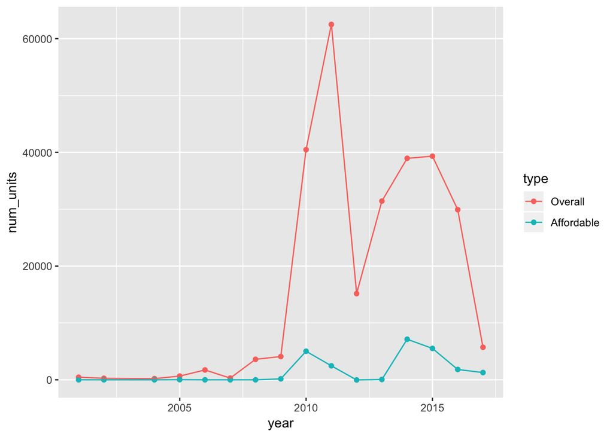

```r
q3.1 %>%
  mutate(year = year(date)) %>%
  group_by(year) %>%
  summarize(
    net_units = sum(net_units, na.rm = TRUE),
    net_aff_units = sum(net_aff_units, na.rm = TRUE)
  ) %>%
  gather(ends_with("units"), key = type, value = num_units, na.rm = TRUE) %>%
  mutate(
    type =
      factor(
        type,
        levels = c("net_units", "net_aff_units"),
        labels = c("Overall", "Affordable")
      )
  ) %>%
  ggplot(aes(year, num_units, color = type)) +
  geom_point() +
  geom_line()
```

The total construction was always much greater than the number of affordable units built. Moreover, the affordable unit construction did not keep pace with overall construction: when overall construction started increasing in 2008, affordable unit construction lagged behind by several years.

There was a dip in construction in 2012, probably due to housing market prices.

**q3.3** Make a heatmap of the net affordable units built in the year 2010, then make another one for the year 2016. Compare these to your map in q1.2. What conclusions can you draw? How might the gentrification typologies have been useful to construction planners back in 2010?

```r
q3.1 %>%
  mutate(year = year(date)) %>%
  filter(year == 2010) %>%
  leaflet() %>%
  addProviderTiles(providers$CartoDB.Positron) %>%
  addHeatmap(
    intensity = ~ net_aff_units,
    radius = 20
  )
```

[interactive chart not shown]

```r
q3.1 %>%
  mutate(year = year(date)) %>%
  filter(year == 2016) %>%
  leaflet() %>%
  addProviderTiles(providers$CartoDB.Positron) %>%
  addHeatmap(
    intensity = ~ net_aff_units,
    radius = 20
  )
```

[interactive chart not shown]

In 2010, construction of affordable units was really only focused on Bayview, a known low-income and underinvested area. However, in 2016, the construction of affordable housing has spread out to areas that very closely match the gentrifying areas seen in q1. If construction planners had known about gentrification typologies sooner, perhaps they could have encouraged more affordable unit construction in gentrifying areas to reduce the negative effects of displacement.

**q4** `file_udp` contains several variables other than the gentrification typologies, which are described under the “_documentation" tab. Explore this data. What conclusions can you draw?

Hints:

- If you’re having trouble looking for a place to start, think about who the gentrifiers could be. Are they of a particular race, or income, or educational attainment level? How can you tell, perhaps by comparison to earlier plots?
- If you are planning to map multiple variables, consider writing a helper function.

```r
plot_across_years <-
  function(start_year_var, end_year_var, start_year, end_year) {
    udp_data %>%
      filter(city == "San Francisco") %>%
      filter(tract_id != 6075017902) %>%
      select(tract_id, !! enquo(start_year_var), !! enquo(end_year_var)) %>%
      gather(key = year, value = value, start_year_var, end_year_var) %>%
      mutate(
        year =
          case_when(
            year == start_year_var ~ start_year,
            year == end_year_var ~ end_year
          )
      ) %>%
      left_join(tracts, by = c("tract_id" = "GEO_ID")) %>%
      ggplot(aes(fill = value)) +
      geom_sf(size = 0.1, color = "white") +
      coord_sf(datum = NA) +
      scale_fill_continuous(
        labels = scales::percent
      ) +
      guides(
        fill =
          guide_colorbar(
            title.hjust = 0.5,
            title.position = "top",
            barwidth = 20
          )
      ) +
      theme_void() +
      theme(
        legend.position = "bottom",
        legend.text = element_text(size = 8)
      ) +
      facet_grid(. ~ year) +
      labs(
        caption = "Source: Urban Displacement Project"
      )
  }
```

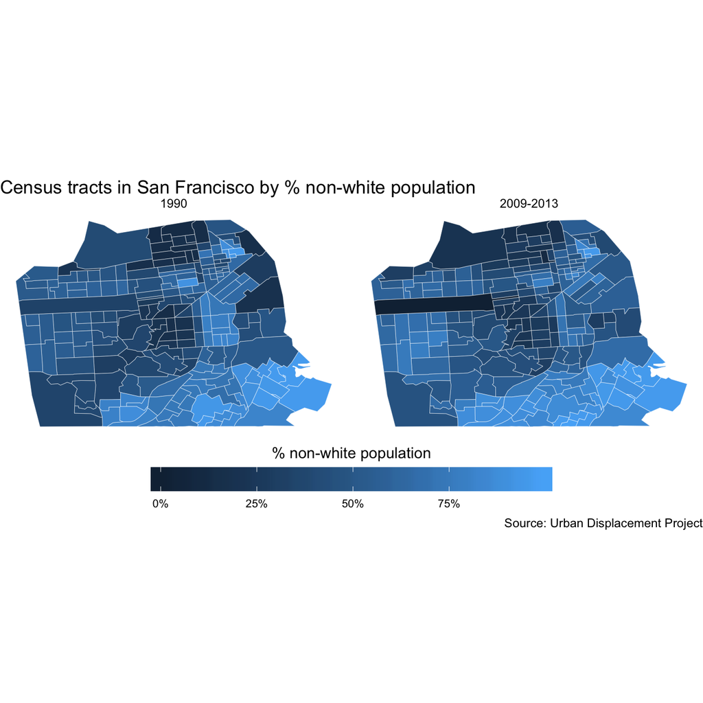

```r
plot_across_years("white_90", "white_13", "1990", "2009-2013") +
  labs(
    title = "Census tracts in San Francisco by % non-white population",
    fill = "% non-white population"
  )
```

Surprisingly, the percentage of non-white people in each census tract does not seem to have changed much in San Francisco since 1990. However, we can see that in the eastern part of the city which is being gentrified, the non-white percentage has decreased slightly. It is possible that this indicates that the gentrifiers are not necessarily white, but simply people with higher income. We can test this using the percentage of college-educated adults.

[output not shown]

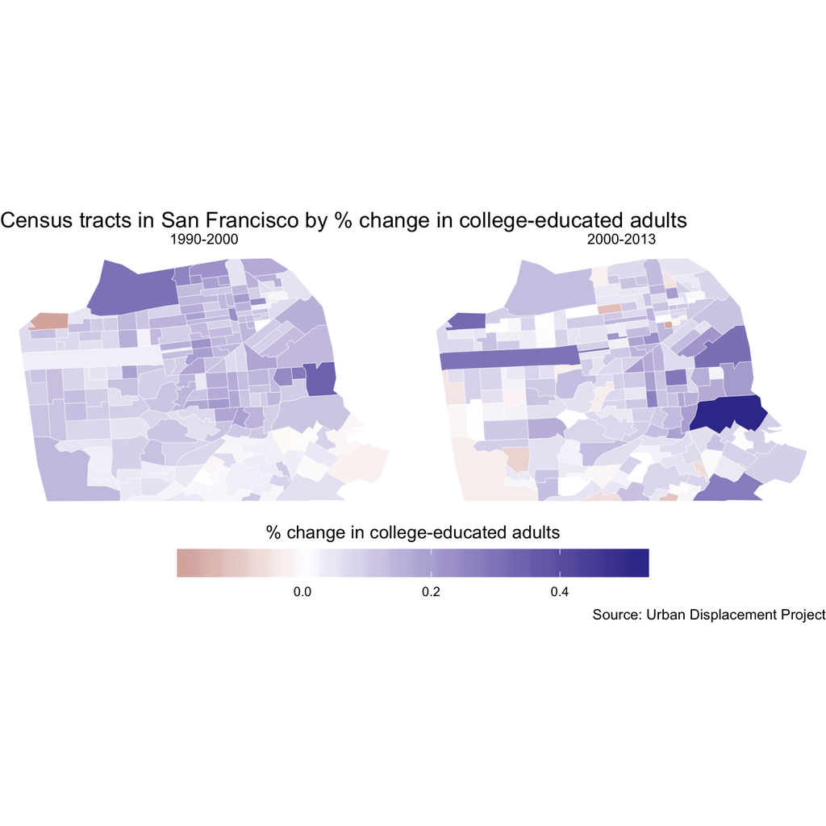

```r
plot_across_years("ed90_00", "ed00_13", "1990-2000", "2000-2013") +
  scale_fill_gradient2() +
  labs(
    title =
      "Census tracts in San Francisco by % change in college-educated adults",
    fill = "% change in college-educated adults"
  )
```

In almost all areas of the city, there has been a positive change in the percentage of college-educated adults, which is perhaps a reflection of better educational attainment overall. However, the map for 2000-2013 shows that this percentage has increased even more in some areas that are being gentrified. This could mean that the gentrifiers are more highly-educated people moving into lower-income districts. Save answers.

```r
if (SAVE_ANSWERS) {
  ls(pattern = "^q[1-9][0-9]*(\\.[1-9][0-9]*)*$") %>%
  str_sort(numeric = TRUE) %>%
  set_names() %>%
  map(get) %>%
  discard(is.ggplot) %>%
  write_rds(file_answers)
}
```